This Jupyter notebook is designed to give an overview for a methodology for extracting job skill importance using revealed preferences from recruiter selected resumes. We begin by selecting only relevant skills by using machine learning, random forest, to select the skills that define a job by classifying the job correctly. We then use the skills selected to fit a logistic regression model that will specify which of the relevant skills, determined through machine learning, make an applicant more likely to be selected by a recruiter.

We begin by selecting only relevant skills by using machine learning, random forest, to select the skills that define a job by classifying the job correctly. We then use the skills selected to fit a logistic regression model that will specify which of the relevant skills, determined through machine learning, make an applicant more likely to be selected by a recruiter.

# Importing and Cleaning

First we read in the data, and optionally remove sparse carotenes using minCut

```python
import pandas as pd
import numpy as np
import random
dataFolder = "Spring/Data/"
job_skill = pd.read_csv(dataFolder + "simdata_2.csv", header = None, dtype = "str", engine = 'c', nrows = 26816994)
job_skill.columns = ["ResumeID", "CaroteneID", "Skill", "Accept"]
job_skill.Skill = job_skill.Skill.str.lower()
CaroteneCounts = job_skill.groupby(["CaroteneID"]).count().reset_index()[["CaroteneID", "ResumeID"]]
minCut = 0
Carotenes = CaroteneCounts.loc[CaroteneCounts['ResumeID'] >= minCut].CaroteneID.unique()
job_skill = job_skill.loc[job_skill['CaroteneID'].isin(Carotenes)]
len(Carotenes)
```

```
6
```

We also remove skills which show up in less than 20% of the observations of a particular job ad. This is useful because it cuts the long tail of non-informative skills without removing relevant skills.

```python
job_skill.Skill = job_skill.Skill.str.lower()
SkillFreq = job_skill.groupby(["CaroteneID", "Skill"]).count().reset_index()
SkillFreq = SkillFreq[["CaroteneID", "Skill", "ResumeID"]]
SkillFreq.columns = ["CaroteneID", "Skill", "SkillFreq"]
JobFreq = job_skill[["CaroteneID", "ResumeID"]].drop_duplicates().reset_index()
JobFreq = JobFreq.groupby(["CaroteneID"]).count().reset_index()
JobFreq = JobFreq[["CaroteneID", "ResumeID"]]
JobFreq.columns = ["CaroteneID", "nJobs"]
TotFreq = JobFreq.merge(SkillFreq)
TotFreq["JobPerc"] = TotFreq["SkillFreq"] / TotFreq["nJobs"]
Skills = TotFreq.loc[TotFreq['JobPerc'] > .20].Skill.unique()
print("Shape before removing skills")
print(job_skill.shape)
job_skill = job_skill.loc[job_skill['Skill'].isin(Skills)]
job_skill = job_skill.loc[job_skill['CaroteneID'].isin(Carotenes)]
print("Shape after removing skills")
print(job_skill.shape)
```

```
Shape before removing skills
(4338, 4)
Shape after removing skills
(1323, 4)
```

The skills and observations are then transformed into a sparse matrix of dummy variables through one-hot encoding. The output shows the skills encoded.

```python
from sklearn.preprocessing import OneHotEncoder
from sklearn.model_selection import train_test_split
train_job_skill, test_job_skill = train_test_split(job_skill, test_size=0.2)
enc = OneHotEncoder(handle_unknown = 'ignore', dtype = bool)
enc.fit(np.array(train_job_skill["Skill"]).reshape(-1, 1))
print(len(enc.get_feature_names()))
enc.get_feature_names()
```

```
54
```

```
array(['x0_abrasive blasting', 'x0_administration', 'x0_analysis',
       'x0_appointment scheduling', 'x0_assembling', 'x0_broadband',
       'x0_cleaning', 'x0_clerical works', 'x0_communications',
       'x0_construction', 'x0_copying', 'x0_curriculums',
       'x0_customer service', 'x0_driving', 'x0_education',
       'x0_engineering', 'x0_english language', 'x0_forklift truck',
       'x0_installations (computer systems)',
       'x0_installations (manual/mechanical)', 'x0_labelling',
       'x0_learning', 'x0_lifting', 'x0_maintenance', 'x0_management',
       'x0_materials', 'x0_metal coating', 'x0_microsoft excel',
       'x0_microsoft powerpoint', 'x0_multilingualism', 'x0_networking',
       'x0_packaging and labeling', 'x0_packing',
       'x0_personally identifiable information', 'x0_photocopying',
       'x0_problem solving', 'x0_product quality control',
       'x0_quality control', 'x0_reliability', 'x0_renovation',
       'x0_repairing (computer systems)', 'x0_sales', 'x0_scanning',
       'x0_scheduling (project management)', 'x0_seal (mechanical)',
       'x0_spanish language', 'x0_stocks (finance)', 'x0_subcontracting',
       'x0_telecommunications', 'x0_television', 'x0_testing',
       'x0_troubleshooting (problem solving)', 'x0_unloading',
       'x0_warehousing'], dtype=object)
```

The encoder then transforms the training and testing data

```python
transformed = enc.transform(np.array(train_job_skill["Skill"]).reshape(-1, 1)).todense()
transformed = pd.DataFrame(transformed)
train_job_skill = pd.concat([train_job_skill.reset_index(drop = True), transformed], axis=1, sort=False)
transformed = enc.transform(np.array(test_job_skill["Skill"]).reshape(-1, 1)).todense()
transformed = pd.DataFrame(transformed)
test_job_skill = pd.concat([test_job_skill.reset_index(drop = True), transformed], axis=1, sort=False)
train_job_skill = train_job_skill.groupby(["CaroteneID", "ResumeID"]).sum()
test_job_skill = test_job_skill.groupby(["CaroteneID", "ResumeID"]).sum()
del(transformed)
```

Here we save the labels into another dataframe and remove them from our training dataframe

```python
CaroteneSkills = pd.DataFrame(train_job_skill.index.values.tolist())
CaroteneSkills.columns = ["CaroteneID", "ResumeID"]
TestCaroteneSkills = pd.DataFrame(test_job_skill.index.values.tolist())
TestCaroteneSkills.columns = ["CaroteneID", "ResumeID"]
x = train_job_skill.reset_index().drop(["CaroteneID", "ResumeID"], axis = 1)
del(train_job_skill)
testx = test_job_skill.reset_index().drop(["CaroteneID", "ResumeID"], axis = 1)
del(test_job_skill)
```

Although not necessary for Sklearn, some machine learning packages require outputs to be numeric. Accordingly, we encode them for flexibility in implementation

```python
from sklearn import preprocessing
le = preprocessing.LabelEncoder()
le.fit(CaroteneSkills.CaroteneID)
binMajor = le.transform(CaroteneSkills.CaroteneID)
TestbinMajor = le.transform(TestCaroteneSkills.CaroteneID)
```

Below we create and train a random forest classifier to discriminate between different jobs by using the presence of particular skills

```python
from sklearn.ensemble import RandomForestClassifier
model = RandomForestClassifier(n_estimators = 100, warm_start = True, n_jobs = -1)
model.fit(x, binMajor)
```

```
RandomForestClassifier(bootstrap=True, class_weight=None, criterion='gini',
            max_depth=None, max_features='auto', max_leaf_nodes=None,
            min_impurity_decrease=0.0, min_impurity_split=None,
            min_samples_leaf=1, min_samples_split=2,
            min_weight_fraction_leaf=0.0, n_estimators=100, n_jobs=-1,
            oob_score=False, random_state=None, verbose=0, warm_start=True)
```

Accuracy can be seen below

```python
print("Accuracy on Training")
print(model.score(x, binMajor))
print("Accuracy on Testing")
print(model.score(testx, TestbinMajor))
```

```
Accuracy on Training
0.9382716049382716
Accuracy on Testing
0.3900709219858156
```

# Random Forest Results

Below, you will find confusion matrices to see class specific results on training and testing data

```python
testpreds = model.predict(testx)
from sklearn.metrics import confusion_matrix
conf = confusion_matrix(testpreds, TestbinMajor)
```

```python
import matplotlib.pyplot as plt

def plot_confusion_matrix(y_true, y_pred, classes,
                          normalize=False,
                          title=None,
                          cmap=plt.cm.Blues):
    """
    This function prints and plots the confusion matrix.
    Normalization can be applied by setting `normalize=True`.
    """
    if not title:
        if normalize:
            title = 'Normalized confusion matrix'
        else:
            title = 'Confusion matrix, without normalization'

    # Compute confusion matrix
    cm = confusion_matrix(y_true, y_pred)
    # Only use the labels that appear in the data
    #classes = classes[unique_labels(y_true, y_pred)]
    if normalize:
        cm = cm.astype('float') / cm.sum(axis=1)[:, np.newaxis]
        print("Normalized confusion matrix")
    else:
        print('Confusion matrix, without normalization')

    #print(cm)

    fig, ax = plt.subplots(figsize=(20,10))
    im = ax.imshow(cm, interpolation='nearest', cmap=cmap)
    ax.figure.colorbar(im, ax=ax)
    # We want to show all ticks...
    ax.set(xticks=np.arange(cm.shape[1]),
           yticks=np.arange(cm.shape[0]),
           # ... and label them with the respective list entries
           xticklabels=classes, yticklabels=classes,
           title=title,
           ylabel='True label',
           xlabel='Predicted label')

    # Rotate the tick labels and set their alignment.
    plt.setp(ax.get_xticklabels(), rotation=45, ha="right",
             rotation_mode="anchor")

    # Loop over data dimensions and create text annotations.
    fmt = '.2f' if normalize else 'd'
    thresh = cm.max() / 2.
    for i in range(cm.shape[0]):
        for j in range(cm.shape[1]):
            ax.text(j, i, format(cm[i, j], fmt),
                    ha="center", va="center",
                    color="white" if cm[i, j] > thresh else "black")
    plt.show()
    return ax
plot_confusion_matrix(testpreds, TestbinMajor, classes=le.classes_, normalize=False,
                      title='Testing Set Confusion matrix, without normalization')
```

[output not shown]

```
Confusion matrix, without normalization
```

```
Normalized confusion matrix
```

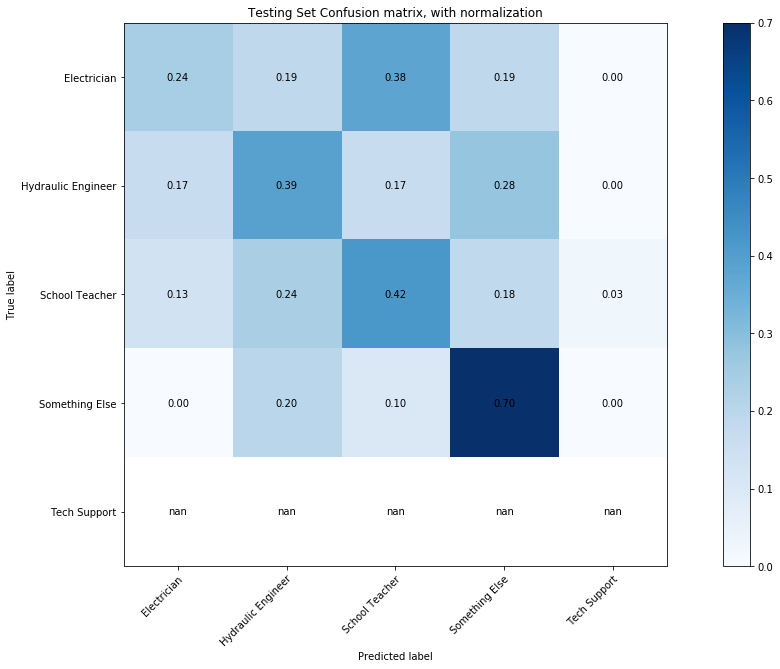

```python
plot_confusion_matrix(testpreds, TestbinMajor, classes=le.classes_, normalize=True,
                      title='Testing Set Confusion matrix, with normalization')
```

```python
testpreds
```

```
array([3, 1, 3, 0, 3, 3, 3, 3, 0, 0, 0, 3, 0, 3, 3, 1, 0, 1, 0, 0, 3, 0,
       0, 3, 4, 1, 1, 0, 3, 3, 0, 3, 3, 3, 3, 1, 3, 3, 1, 4, 1, 3, 3, 3,
       3, 0, 1, 0, 3, 3, 3, 1, 0, 3, 0, 3, 1, 0, 3, 0, 3, 0, 0, 3, 3, 3,
       1, 4, 1, 3, 0, 3, 3, 3, 0, 0, 3, 3, 3, 0, 3, 3, 3, 3, 3, 0, 3, 3,
       3, 3, 3, 3, 3, 3, 3, 3, 0, 0, 3, 0, 0, 3, 3, 0, 3, 3, 4, 3, 1, 3,
       3, 3, 0, 1, 1, 1, 3, 3, 0, 3, 4, 3, 3, 0, 3, 3, 1, 4, 0, 3, 4, 4,
       3, 0, 0, 4, 4, 3, 0, 3, 3])
```

```python
trainPreds = model.predict(x)
trainPreds
```

```
array([0, 0, 3, 0, 0, 0, 0, 0, 0, 0, 0, 0, 0, 1, 0, 0, 0, 0, 0, 0, 0, 0,
       0, 0, 3, 0, 0, 0, 0, 0, 0, 3, 0, 0, 0, 0, 3, 0, 3, 0, 0, 0, 0, 0,
       0, 0, 0, 3, 0, 0, 0, 0, 1, 1, 1, 1, 1, 1, 1, 1, 1, 1, 1, 1, 1, 1,
       1, 1, 1, 1, 1, 1, 1, 1, 1, 1, 1, 1, 1, 1, 1, 1, 1, 1, 1, 1, 1, 1,
       1, 1, 1, 1, 1, 1, 1, 0, 1, 1, 1, 1, 1, 1, 0, 3, 3, 3, 3, 3, 3, 3,
       3, 3, 3, 3, 3, 3, 3, 3, 3, 0, 3, 3, 3, 3, 3, 3, 3, 3, 3, 3, 3, 3,
       3, 3, 3, 3, 3, 3, 3, 3, 3, 1, 3, 3, 3, 3, 3, 3, 3, 3, 3, 3, 3, 3,
       3, 3, 3, 3, 3, 0, 3, 3, 3, 3, 3, 3, 3, 3, 3, 3, 3, 3, 3, 3, 3, 0,
       3, 3, 3, 3, 3, 3, 3, 3, 3, 3, 3, 3, 3, 3, 3, 4, 4, 4, 4, 4, 4, 4,
       4, 4, 4, 4, 4, 4, 4, 4, 4, 4, 4, 4, 4, 0, 4, 4, 4, 4, 4, 4, 4, 4,
       4, 3, 4, 4, 4, 4, 4, 4, 4, 4, 4, 4, 4, 4, 4, 4, 4, 4, 4, 4, 5, 5,
       5])
```

```
Normalized confusion matrix
```

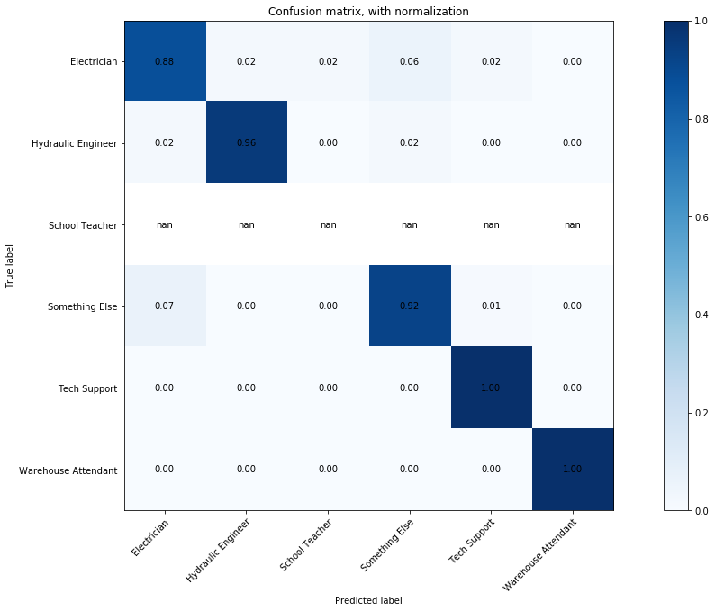

```python
plot_confusion_matrix(trainPreds, binMajor, classes= le.classes_, normalize=True,
                      title='Confusion matrix, with normalization')
```

```python
trainPreds = model.predict(x)
```

# Feature Importances

Ensemble classifiers' weights are available. Below we use classification weights to determine relevant skills for particular jobs

```python
model.feature_importances_
```

```
array([0.00517331, 0.02680318, 0.0209919 , 0.01917085, 0.01206666,
       0.03366601, 0.02038618, 0.00620494, 0.03189872, 0.02564869,
       0.00430491, 0.00370234, 0.0320261 , 0.0109619 , 0.01542702,
       0.02944486, 0.02034539, 0.03177474, 0.03399756, 0.02801626,
       0.00676639, 0.02038414, 0.01367158, 0.03127587, 0.03707802,
       0.02415124, 0.00530064, 0.02105285, 0.0262465 , 0.00589333,
       0.00882726, 0.00846043, 0.01375719, 0.0076143 , 0.00045149,
       0.01943853, 0.00283131, 0.00912481, 0.00017426, 0.024457  ,
       0.04046062, 0.02380552, 0.0130129 , 0.02297524, 0.00423043,
       0.00755631, 0.01197668, 0.03487403, 0.04293656, 0.02093534,
       0.01455219, 0.01160012, 0.02826145, 0.02385394])
```

```python
from sklearn.preprocessing import scale

def class_feature_importance(X, Y, feature_importances):
    N, M = X.shape
    X = scale(X)

    out = {}
    for c in set(Y):
        out[c] = dict(
            zip(range(N), np.mean(X[Y==c, :], axis=0)*feature_importances)
        )

    return out
```

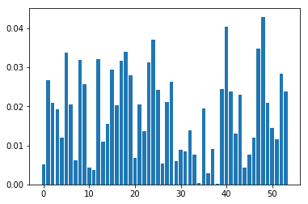

```python
import matplotlib.pyplot as pyplot
pyplot.bar(range(len(model.feature_importances_)), model.feature_importances_)
pyplot.show()
```

```python
imp = class_feature_importance(testx, TestbinMajor, model.feature_importances_)
imp
```

```
{0: {0: 0.0,
  1: 0.002758349073887703,
  2: 0.0035171442719028937,
  3: -0.002826587994057731,
  4: -0.0014474208061645603,
  5: -0.004963782092097389,
  6: -0.0003933281524969156,
  7: -0.0007442953290240441,
  8: -0.003872611715307051,
  9: -0.006290489277714715,
  10: -0.0005163830360520113,
  11: 0.0,
  12: -0.003177406933728266,
  13: -0.0009264498061424426,
  14: 0.005811265181530209,
```

[output cut: 255 more lines]

```python
list(imp.keys())
```

```
[0, 1, 3, 4, 5]
```

```python
le.inverse_transform(list(imp.keys()))
```

```
array(['Electrician', 'Hydraulic Engineer', 'Something Else',
       'Tech Support', 'Warehouse Attendant'], dtype=object)
```

```python
for k in list(imp.keys()):
    hold = imp[k]
    del imp[k]
    k = le.inverse_transform([k])[0]
    imp[k] = hold
imp
```

```
{'Electrician': {0: 0.0,
  1: 0.002758349073887703,
  2: 0.0035171442719028937,
  3: -0.002826587994057731,
  4: -0.0014474208061645603,
  5: -0.004963782092097389,
  6: -0.0003933281524969156,
  7: -0.0007442953290240441,
  8: -0.003872611715307051,
  9: -0.006290489277714715,
  10: -0.0005163830360520113,
  11: 0.0,
  12: -0.003177406933728266,
  13: -0.0009264498061424426,
  14: 0.005811265181530209,
```

[output cut: 255 more lines]

```python
for k_prime in imp.keys():
    for k in list(imp[k_prime].keys()):
        hold = imp[k_prime][k]
        del imp[k_prime][k]
        k = enc.categories_[0][k]
        imp[k_prime][k] = hold
```

For the remainder of the example, we will focus on Tech Support jobs

```python
imp['Tech Support']
```

```
{'abrasive blasting': 0.0,
 'administration': -0.004579900349096572,
 'analysis': 0.0013130671948437464,
 'appointment scheduling': 0.0011991585429335814,
 'assembling': 0.0016447963706415429,
 'broadband': 0.01624510502868236,
 'cleaning': -0.00465942580650192,
 'clerical works': -0.000744295329024044,
 'communications': 0.012346346260681896,
 'construction': -0.006290489277714712,
 'copying': -0.0005163830360520113,
 'curriculums': 0.0,
 'customer service': -0.005067762957591917,
 'driving': 0.0030320175473752668,
 'education': -0.002636037814302362,
 'engineering': 0.004742676814666511,
 'english language': -0.0032194240395635406,
 'forklift truck': -0.005027988307671738,
 'installations (computer systems)': 0.01640508912280731,
 'installations (manual/mechanical)': 0.007808121970152405,
 'labelling': 0.0,
 'learning': 0.00023748204116215668,
 'lifting': -0.0011554596383584008,
 'maintenance': -0.00013940232251845607,
 'management': -0.001470233793131199,
 'materials': 0.00028136995136120727,
 'metal coating': 0.0,
 'microsoft excel': -0.0013665133094496339,
 'microsoft powerpoint': -0.0015929049433898736,
 'multilingualism': -0.0007069169255814688,
 'networking': 0.006602864024068079,
 'packaging and labeling': -0.0010148457052874616,
 'packing': -0.0026378217045597277,
 'personally identifiable information': 0.0,
 'photocopying': -5.415705205452059e-05,
 'problem solving': 0.004563020958552461,
 'product quality control': -0.00023928907736858924,
 'quality control': -0.0010945391251701306,
 'reliability': -1.4727890625541585e-05,
 'renovation': -0.0036059886512434364,
 'repairing (computer systems)': 0.005515151015007755,
 'sales': 0.011490208594863733,
 'scanning': 0.0,
 'scheduling (project management)': -0.003151102788795922,
 'seal (mechanical)': 0.0,
 'spanish language': -0.0015930106729162572,
 'stocks (finance)': -0.0010122139078539189,
 'subcontracting': -0.005141895872015626,
 'telecommunications': 0.016855617906842264,
 'television': 0.0057906292576792515,
 'testing': 0.004794654434014712,
 'troubleshooting (problem solving)': 0.0038220057563655833,
 'unloading': -0.005027655669578864,
 'warehousing': -0.0046849061467745395}
```

```python
Skills = pd.DataFrame.from_dict(imp, orient='columns')#, columns=['Score'])
Skills
```

|  | Electrician | Hydraulic Engineer | Something Else | Tech Support | Warehouse Attendant |
| --- | --- | --- | --- | --- | --- |
| abrasive blasting | 0.000000 | 0.000000 | 0.000000 | 0.000000 | 0.000000 |
| administration | 0.002758 | 0.004917 | -0.001351 | -0.004580 | -0.004580 |
| analysis | 0.003517 | 0.001183 | -0.003095 | 0.001313 | -0.003095 |
| appointment scheduling | -0.002827 | -0.002827 | 0.002487 | 0.001199 | -0.002827 |
| assembling | -0.001447 | -0.001447 | 0.000593 | 0.001645 | -0.001447 |
| broadband | -0.004964 | -0.004964 | -0.004964 | 0.016245 | -0.004964 |
| cleaning | -0.000393 | -0.001899 | 0.004726 | -0.004659 | -0.004659 |
| clerical works | -0.000744 | -0.000744 | 0.000305 | -0.000744 | 0.025492 |
| communications | -0.003873 | -0.005781 | -0.002143 | 0.012346 | -0.009279 |
| construction | -0.006290 | 0.010014 | 0.000362 | -0.006290 | -0.006290 |
| copying | -0.000516 | 0.000554 | -0.000516 | -0.000516 | 0.017686 |
| curriculums | 0.000000 | 0.000000 | 0.000000 | 0.000000 | 0.000000 |
| customer service | -0.003177 | 0.002160 | 0.003628 | -0.005068 | -0.008848 |
| driving | -0.000926 | -0.000926 | -0.000926 | 0.003032 | -0.000926 |
| education | 0.005811 | 0.000097 | -0.000778 | -0.002636 | -0.002636 |
| engineering | 0.001416 | 0.004351 | -0.006369 | 0.004743 | -0.008565 |
| english language | -0.002019 | 0.006035 | -0.000866 | -0.003219 | -0.005621 |
| forklift truck | 0.024980 | -0.008779 | -0.001352 | -0.005028 | -0.008779 |
| installations (computer systems) | -0.005013 | -0.005013 | -0.005013 | 0.016405 | -0.005013 |
| installations (manual/mechanical) | -0.006871 | 0.007376 | -0.006871 | 0.007808 | -0.006871 |
| labelling | 0.000000 | 0.000000 | 0.000000 | 0.000000 | 0.000000 |
| learning | 0.002098 | -0.003483 | -0.001028 | 0.000237 | 0.057906 |
| lifting | 0.006250 | -0.001155 | -0.001155 | -0.001155 | -0.001155 |
| maintenance | -0.005053 | 0.005931 | -0.001319 | -0.000139 | -0.009967 |
| management | 0.000175 | 0.001336 | 0.000570 | -0.001470 | -0.014632 |
| materials | -0.004127 | 0.008709 | -0.004127 | 0.000281 | -0.004127 |
| metal coating | 0.000000 | 0.000000 | 0.000000 | 0.000000 | 0.000000 |
| microsoft excel | -0.002556 | 0.010037 | -0.004554 | -0.001367 | -0.006124 |
| microsoft powerpoint | 0.000377 | 0.002116 | -0.000332 | -0.001593 | -0.005533 |
| multilingualism | -0.000707 | 0.000759 | 0.000290 | -0.000707 | -0.000707 |
| networking | -0.002018 | -0.002018 | -0.002018 | 0.006603 | -0.002018 |
| packaging and labeling | -0.001015 | -0.001015 | 0.001847 | -0.001015 | -0.001015 |
| packing | -0.002638 | -0.002638 | 0.004801 | -0.002638 | -0.002638 |
| personally identifiable information | 0.000000 | 0.000000 | 0.000000 | 0.000000 | 0.000000 |
| photocopying | 0.000119 | -0.000054 | -0.000054 | -0.000054 | 0.001855 |
| problem solving | -0.001461 | -0.002737 | -0.000305 | 0.004563 | -0.005076 |
| product quality control | -0.000239 | -0.000239 | -0.000239 | -0.000239 | 0.016631 |
| quality control | -0.001095 | 0.001175 | 0.000449 | -0.001095 | -0.001095 |
| reliability | -0.000015 | -0.000015 | -0.000015 | -0.000015 | 0.001024 |
| renovation | -0.003606 | 0.006364 | -0.000216 | -0.003606 | -0.003606 |
| repairing (computer systems) | 0.010699 | -0.004853 | -0.004853 | 0.005515 | -0.004853 |
| sales | -0.006216 | -0.000488 | -0.004268 | 0.011490 | -0.006216 |
| scanning | 0.000000 | 0.000000 | 0.000000 | 0.000000 | 0.000000 |
| scheduling (project management) | 0.002545 | 0.002294 | -0.000360 | -0.003151 | -0.005999 |
| seal (mechanical) | 0.000000 | 0.000000 | 0.000000 | 0.000000 | 0.000000 |
| spanish language | 0.000109 | 0.001710 | -0.000096 | -0.001593 | -0.001593 |
| stocks (finance) | 0.005475 | -0.001012 | -0.001012 | -0.001012 | -0.001012 |
| subcontracting | -0.005142 | 0.016182 | -0.005142 | -0.005142 | -0.005142 |
| telecommunications | -0.005150 | -0.005150 | -0.005150 | 0.016856 | -0.005150 |
| television | -0.001769 | -0.001769 | -0.001769 | 0.005791 | -0.001769 |
| testing | -0.003326 | -0.001356 | -0.000646 | 0.004795 | -0.003326 |
| troubleshooting (problem solving) | -0.002651 | 0.000490 | -0.001583 | 0.003822 | -0.002651 |
| unloading | 0.006149 | -0.008221 | 0.006532 | -0.005028 | -0.008221 |
| warehousing | 0.012153 | -0.007275 | 0.002983 | -0.004685 | -0.007275 |

Below, we filter out job skills relevant to Tech Support positions. Relevance is defined as having a classification weight greater than 0. This subset of skills will be used to further explore skill importance

```python
Skills = pd.DataFrame.from_dict(imp['Tech Support'], orient='index', columns=['Score'])
Skills = Skills.reset_index()
Skills = Skills.merge(pd.DataFrame(x[binMajor == 0].sum()), left_index = True, right_index=True)
Skills.columns = ["Skill", "Score", "Frequency"]
Skills["Joined"] = Skills.Score * Skills.Frequency
#Electrician
Skills.sort_values(by = "Joined", ascending = False)
UsefulSkills = Skills.loc[Skills.Score > 0].Skill
```

Below, we apply the same cleaning techniques as earlier with the addition of filtering for skills that were found to be relevant to classification. Relevant skills are used here as predictors for selection by a recruiter. The output shows the coefficients, and associated skill. Higher coefficients correspond to more important skills. Accordingly, the skills are presented in descending order of coefficient, effectively giving a ranked list of skills.

```python
job_skill = pd.read_csv(dataFolder + "simdata_2.csv", header = None, dtype = "str", engine = 'c', nrows = 26816994)
job_skill.columns = ["ResumeID", "CaroteneID", "Skill", "Accept"]
job_skill.Skill = job_skill.Skill.str.lower()
job_skill = job_skill.loc[job_skill.CaroteneID == "Tech Support"]
job_skill = job_skill.loc[job_skill.Skill.isin(UsefulSkills)]
enc = OneHotEncoder(handle_unknown = 'ignore', dtype = bool)
enc.fit(np.array(job_skill["Skill"]).reshape(-1, 1))
transformed = enc.transform(np.array(job_skill["Skill"]).reshape(-1, 1)).todense()
transformed = pd.DataFrame(transformed)
job_skill = pd.concat([job_skill.reset_index(drop = True), transformed], axis=1, sort=False)
job_skill = job_skill.groupby(["Accept", "ResumeID"]).sum()
x = job_skill.reset_index().drop(["Accept", "ResumeID"], axis = 1)
y = job_skill.reset_index().Accept
from sklearn.linear_model import LogisticRegression
lm = LogisticRegression(class_weight = 'balanced')
lm.fit(x, y)
RelevantSkills = pd.DataFrame([enc.categories_[0], lm.coef_[0]]).T.sort_values(by = 1, ascending = False)
RelevantSkills
```

|  | 0 | 1 |
| --- | --- | --- |
| 3 | broadband | 1.62621 |
| 18 | troubleshooting (problem solving) | 0.915718 |
| 11 | networking | 0.620526 |
| 14 | sales | 0.566442 |
| 7 | installations (computer systems) | 0.506235 |
| 17 | testing | 0.359815 |
| 15 | telecommunications | 0.329315 |
| 1 | appointment scheduling | 0.229332 |
| 13 | repairing (computer systems) | 0.134495 |
| 16 | television | -0.0178758 |
| 12 | problem solving | -0.085324 |
| 4 | communications | -0.200655 |
| 0 | analysis | -0.206564 |
| 9 | learning | -0.220732 |
| 5 | driving | -0.29631 |
| 6 | engineering | -0.427397 |
| 8 | installations (manual/mechanical) | -0.46813 |
| 10 | materials | -0.552023 |
| 2 | assembling | -0.943615 |